# Overall Performance for Included vs Excluded Participants

Alex Kale

7/22/2020

This document provides a summary of overall performance on both the estimation and decision tasks in our study. It also compares these metrics for included vs excluded participants.

## Load and Prepare Data

We load worker responses from our experiment and do some preprocessing.

```r
# read in data
full_df <- read_csv("experiment-anonymous.csv")
```

```r
# preprocessing
responses_df <- full_df %>%
  rename( # rename to convert away from camel case
    worker_id = workerId,
    ground_truth = groundTruth,
    sd_diff = sdDiff,
    p_award_with = pAwardWith,
    p_award_without = pAwardWithout,
    account_value = accountValue,
    p_superiority = pSup,
    start_time = startTime,
    resp_time = respTime,
    trial_dur = trialDur,
    trial_idx = trialIdx
  ) %>%
  # remove practice and mock trials from responses dataframe, leave in full version
  filter(trial_idx != "practice", trial_idx != "mock") %>%
  # mutate rows where intervene == -1 for some reason
  mutate(
    intervene = if_else(intervene == -1,
                        # repair
                        if_else((payoff == (award_value - 1) | payoff == -1),
                                1, # payed for intervention
                                0), # didn't pay for intervention
                        # don't repair
                        as.numeric(intervene) # hack to avoid type error
                        )
  ) #%>%
  # # set up factors for modeling
  # mutate(
  #   # add a variable to note whether the chart they viewed showed means
  #   means = as.factor((start_means & as.numeric(trial) <= (n_trials / 2)) | (!start_means & as.numeric(trial) > (n_trials / 2))),
  #   start_means = as.factor(start_means),
  #   sd_diff = as.factor(sd_diff),
  #   trial_number = as.numeric(trial)
  # )

head(responses_df)
```

```
## # A tibble: 6 x 36
##   worker_id batch n_trials n_data_conds condition baseline es_threshold
##   <chr>     <dbl>    <dbl>        <dbl> <chr>        <dbl>        <dbl>
## 1 7819bfb6     17       34           18 intervals      0.5          0.9
## 2 7819bfb6     17       34           18 intervals      0.5          0.9
## 3 7819bfb6     17       34           18 intervals      0.5          0.9
## 4 7819bfb6     17       34           18 intervals      0.5          0.9
## 5 7819bfb6     17       34           18 intervals      0.5          0.9
## 6 7819bfb6     17       34           18 intervals      0.5          0.9
## # … with 29 more variables: start_means <lgl>, award_value <dbl>,
## #   starting_value <dbl>, exchange <dbl>, cutoff <dbl>, max_bonus <dbl>,
## #   total_bonus <dbl>, duration <dbl>, numeracy <dbl>, gender <chr>, age <chr>,
## #   education <chr>, chart_use <chr>, strategy_with_means <chr>,
## #   strategy_without_means <chr>, account_value <dbl>, ground_truth <dbl>,
## #   intervene <dbl>, outcome <lgl>, p_award_with <dbl>, p_award_without <dbl>,
## #   p_superiority <dbl>, payoff <dbl>, resp_time <dbl>, sd_diff <dbl>,
## #   start_time <dbl>, trial <chr>, trial_dur <dbl>, trial_idx <chr>
```

Now, lets apply our exclusion criteria, adding a row to our dataframe that we can use to split our sample into subsets of included and excluded participants.

```r
# determine exclusions
exclude_df <- responses_df %>%
  # attention check trials where ground truth = c(0.5, 0.999)
  mutate(failed_check = (ground_truth == 0.5 & intervene != 0) | (ground_truth == 0.999 & intervene != 1)) %>%
  group_by(worker_id) %>%
  summarise(
    failed_attention_checks = sum(failed_check),
    unique_p_sup = length(unique(p_superiority)),
    # exclude if they failed either attention check, used fewer than three levels of the response scale, or were one of four participants with too many missing responses to fit our models
    exclude = failed_attention_checks > 0 | unique_p_sup < 3 | unique(worker_id) %in% c("c488db75", "ce016e09", "f430e2e8", "c337674a")
  ) %>%
  dplyr::select(worker_id, exclude)

# apply exclusion criteria and remove attention check trials from dataset
responses_df <- responses_df %>%
  left_join(exclude_df, by = "worker_id") %>%
  filter(ground_truth > 0.5 & ground_truth < 0.999)

# how participants excluded vs not?
responses_df %>%
  group_by(exclude) %>%
  summarise(
    n_workers = length(unique(worker_id))
  )
```

```
## # A tibble: 2 x 2
##   exclude n_workers
##   <lgl>       <int>
## 1 FALSE         622
## 2 TRUE          257
```

Now we have our dataset ready.

## Summary Statistics for Overall Performance

To summarize performance on probability of superiority judgments, we’ll look at absolute error.

```r
# add error and absolute error to df
responses_df <- responses_df %>%
  mutate(abs_err_p_sup = abs(p_superiority - ground_truth * 100))
```

In order to see how people are doing on the decision task, we will benchmark their performance against the utility optimal decision rule on our task

```r
# determine whether or not intervention is utility optimal on each trial
responses_df <- responses_df %>%
  mutate(
    should_intervene = (p_award_with - p_award_without) > 1 / award_value, # decision rule
    correct = intervene == should_intervene
  )
```

## Analysis of Overall Performance

Reviewers of our paper asked about overall performance for included vs excluded participants.

### Estimation Task

Let’s start by showing absolute error in probability of superiority estimates per condition for included vs excluded participants.

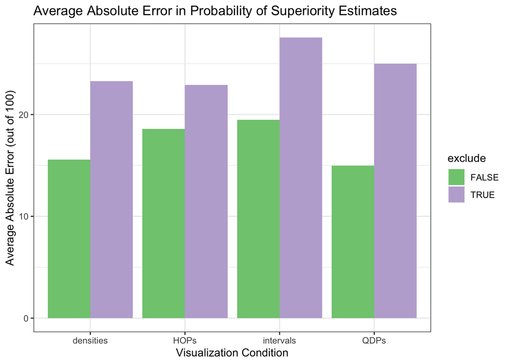

```r
responses_df %>%
  group_by(condition, exclude) %>%
  summarise(avg_abs_err_p_sup = mean(abs_err_p_sup)) %>%
  ggplot(aes(x = condition, y = avg_abs_err_p_sup, fill = exclude)) +
    geom_bar(stat = "identity", position = position_dodge()) +
    scale_fill_brewer(type = "qual", palette = 1) +
    theme_bw() +
    labs(title = "Average Absolute Error in Probability of Superiority Estimates",
        x = "Visualization Condition",
        y = "Average Absolute Error (out of 100)"
    )
```

Let’s also look at this summary statistic for included vs excluded participants regardless of condition.

```r
# collapsing across conditions
responses_df %>%
  group_by(exclude) %>%
  summarise(avg_abs_err_p_sup = mean(abs_err_p_sup))
```

```
## # A tibble: 2 x 2
##   exclude avg_abs_err_p_sup
##   <lgl>               <dbl>
## 1 FALSE                17.2
## 2 TRUE                 24.7
```

We can see that average absolute error for included participants is about 17%, about 8% lower than for excluded participants. This suggests both that the probability of superiority judgment was difficult for participants and that our exclusion criteria successfully selected against participants with an especially poor understanding of the task.

To get a more granular understanding of performance, let’s look at the average probability of superiority estimate vs ground truth for included vs excluded participants in each condition.

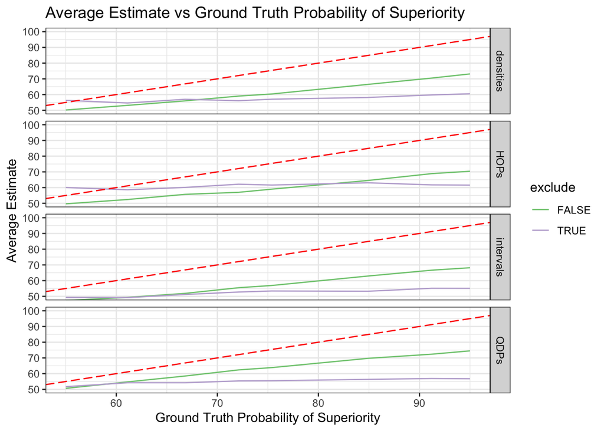

```r
responses_df %>%
  group_by(condition, exclude, ground_truth) %>%
  summarise(avg_p_sup = mean(p_superiority)) %>%
  ggplot(aes(x = ground_truth * 100, y = avg_p_sup, color = exclude)) +
    geom_line() +
    geom_abline(aes(intercept = 0, slope = 1), color = "red", linetype ="longdash") +
    scale_color_brewer(type = "qual", palette = 1) +
    theme_bw() +
    labs(title = "Average Estimate vs Ground Truth Probability of Superiority",
        x = "Ground Truth Probability of Superiority",
        y = "Average Estimate"
    ) +
    coord_cartesian(ylim = c(50, 100)) +
    facet_grid(condition ~ .)
```

The red dashed line depicts perfect performance. We can see that excluded participants in all conditions were less sensitive to the ground truth than included participants. This suggests that adding excluded participants to our analysis would have resulted in an exaggeration of users’ tendency to underestimate effect size, which would have severly limited our statistical power to detect differences in performance between visualization designs.

### Decision Task

Now, let’s look at overall performance on our decision task in terms of the proportion of “correct” or utility optimal decisions.

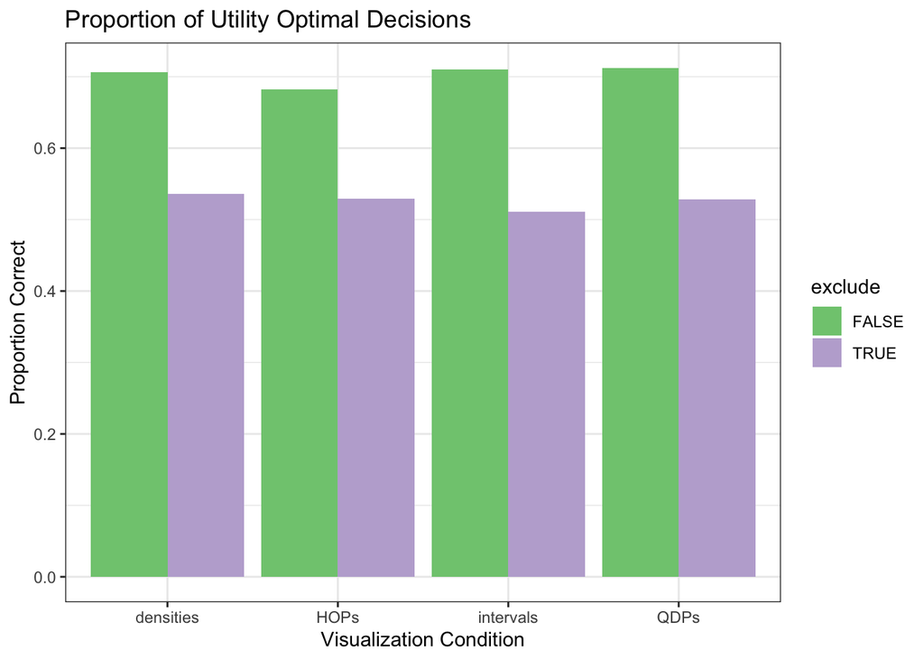

```r
responses_df %>%
  group_by(condition, exclude) %>%
  summarise(proportion_correct = sum(correct) / n()) %>%
  ggplot(aes(x = condition, y = proportion_correct, fill = exclude)) +
    geom_bar(stat = "identity", position = position_dodge()) +
    scale_fill_brewer(type = "qual", palette = 1) +
    theme_bw() +
    labs(title = "Proportion of Utility Optimal Decisions",
        x = "Visualization Condition",
        y = "Proportion Correct"
    )
```

Let’s also look at this summary statistic for included vs excluded participants regardless of condition.

```r
# collapsing across conditions
responses_df %>%
  group_by(exclude) %>%
  summarise(proportion_correct = sum(correct) / n())
```

```
## # A tibble: 2 x 2
##   exclude proportion_correct
##   <lgl>                <dbl>
## 1 FALSE                0.703
## 2 TRUE                 0.526
```

We can see that included participants seem to perform much better on the decision task (70% correct) than excluded participants (53% correct). We expect the decision task to be very difficult for the 1/4th of trials that were close to the utility-optimal decision threshold of 74% probability of superiority. In light of the way we sampled the ground truth, making the utility-optimal decision on 70% of trials is surprisingly good overall performance. This suggests that the participants included in our analysis did seem to understand the decision task.